# Parole Reform

MUSA 5080 · Fall 2026

Author

Sara Cerami

Published

November 26, 2026

# Part 1: Load and clean

```r
library(tidyverse)

nij <- read_csv("C:/MUSA/public policy analysis/MUSA-5080-portfolio/data/nij_recidivism.csv") %>%
  mutate(
    recid              = as.integer(Recidivism_Within_3years == "Yes"),
    male               = as.integer(Gender == "M"),
    age_group          = factor(Age_at_Release),
    prison_years       = factor(Prison_Years,
                                levels = c("Less than 1 year", "1-2 years",
                                           "Greater than 2 to 3 years",
                                           "More than 3 years")),
    prior_fel_arrests  = parse_number(Prior_Arrest_Episodes_Felony),
    prior_misd_arrests = parse_number(Prior_Arrest_Episodes_Misd),
    puma               = factor(Residence_PUMA)
  )

train <- nij %>% filter(Training_Sample == 1)
test  <- nij %>% filter(Training_Sample == 0)
```

```r
nrow(train)
```

```
[1] 18028
```

```r
table(train$Recidivism_Within_3years)
```

```
   No   Yes
 7607 10421
```

```r
nrow(test)
```

```
[1] 7807
```

```r
table(test$Recidivism_Within_3years)
```

```
  No  Yes
3324 4483
```

The train data has 18,028 individuals and of those, 10,421 were rearrested within three years. The test data has 7,807 individuals and of those, 4,483 were rearrested within three years.

```r
library(dplyr)

str(train$Gang_Affiliated)
```

```
 chr [1:18028] "No" "No" "No" "No" "No" "No" NA "No" "No" "No" "Yes" "No" ...
```

```r
str(train$Gender)
```

```
 chr [1:18028] "M" "M" "M" "M" "M" "M" "F" "M" "M" "M" "M" "M" "M" "M" "M" ...
```

```r
table(train$Gang_Affiliated, train$Gender, useNA = "ifany")
```

```
           F     M
  No       0 13030
  Yes      0  2781
  <NA>  2217     0
```

There are 2,217 values missing from the Gang_Affiliated column and they are all Women. In fact, no women are identified as definitively gang affiliated or definitively not gang affiliated in the data, which leads me to believe women are not asked about gang affiliation or their answers are not documented as part of the data collection process. If these individuals were dropped from the dataset as a result of missing values, there would be no women included in the data.

# Part 2

I imagine that the data measuring failure to report probationary violations occur after release. Including data from after release for a prediction model that is intended for upon release decisions will make the model look better than it really is. In other words, the model will not have post release data when calculating risk because they do not exist yet. If I were to include this data point as a predictor, it would be bound up in the outcome, risking inflated success.

# Part 3

```r
base_fit <- glm(recid ~ male + age_group + prison_years +
                  prior_fel_arrests + prior_misd_arrests,
                family = binomial,
                data = train)

summary(base_fit)
```

```
Call:
glm(formula = recid ~ male + age_group + prison_years + prior_fel_arrests +
    prior_misd_arrests, family = binomial, data = train)

Coefficients:
                                       Estimate Std. Error z value Pr(>|z|)
(Intercept)                           -0.031637   0.078824  -0.401  0.68815
male                                   0.454123   0.049610   9.154  < 2e-16 ***
age_group23-27                        -0.505516   0.070835  -7.137 9.57e-13 ***
age_group28-32                        -1.062281   0.072975 -14.557  < 2e-16 ***
age_group33-37                        -1.448176   0.076123 -19.024  < 2e-16 ***
age_group38-42                        -1.678820   0.081802 -20.523  < 2e-16 ***
age_group43-47                        -1.910151   0.084204 -22.685  < 2e-16 ***
age_group48 or older                  -2.290828   0.080526 -28.448  < 2e-16 ***
prison_years1-2 years                 -0.124180   0.041760  -2.974  0.00294 **
prison_yearsGreater than 2 to 3 years -0.304194   0.049685  -6.122 9.22e-10 ***
prison_yearsMore than 3 years         -0.319948   0.047298  -6.765 1.34e-11 ***
prior_fel_arrests                      0.167507   0.006573  25.483  < 2e-16 ***
prior_misd_arrests                     0.131496   0.008719  15.081  < 2e-16 ***
---
Signif. codes:  0 '***' 0.001 '**' 0.01 '*' 0.05 '.' 0.1 ' ' 1

(Dispersion parameter for binomial family taken to be 1)

    Null deviance: 24551  on 18027  degrees of freedom
Residual deviance: 21940  on 18015  degrees of freedom
AIC: 21966

Number of Fisher Scoring iterations: 4
```

**3.1**

```r
exp(coef(base_fit))
```

```
                          (Intercept)                                  male
                            0.9688582                             1.5747917
                       age_group23-27                        age_group28-32
                            0.6031942                             0.3456664
                       age_group33-37                        age_group38-42
                            0.2349986                             0.1865940
                       age_group43-47                  age_group48 or older
                            0.1480580                             0.1011826
                prison_years1-2 years prison_yearsGreater than 2 to 3 years
                            0.8832206                             0.7377176
        prison_yearsMore than 3 years                     prior_fel_arrests
                            0.7261868                             1.1823530
                   prior_misd_arrests
                            1.1405337
```

The exponentiated coefficient for prior felony arrests is 1.18. This means that each additional felony arrest multiplies the odds of rearrest by about 18%, holding all other variables constant.

**3.2**

```r
people <- tibble(
  male               = c(1, 1),
  age_group          = factor(c("23-27", "48 or older"), levels = levels(nij$age_group)),
  prison_years       = factor(c("1-2 years", "1-2 years"), levels = levels(nij$prison_years)),
  prior_fel_arrests  = c(2, 2),
  prior_misd_arrests = c(1, 1)
)

p_before <- predict(base_fit, newdata = people, type = "response")

people_plus_one <- people %>% mutate(prior_fel_arrests = prior_fel_arrests + 1)
p_after <- predict(base_fit, newdata = people_plus_one, type = "response")

tibble(
  person = c("Age 23-27", "Age 48+"),
  p_before = p_before,
  p_after = p_after,
  change = p_after - p_before
)
```

```
# A tibble: 2 × 4
  person    p_before p_after change
  <chr>        <dbl>   <dbl>  <dbl>
1 Age 23-27    0.564   0.605 0.0406
2 Age 48+      0.179   0.204 0.0259
```

**3.3**

```r
my_fit <- glm(recid ~ male + age_group + prison_years +
                  prior_fel_arrests + prior_misd_arrests + Prior_Arrest_Episodes_Drug + Condition_MH_SA + Education_Level,
                family = binomial,
                data = train)

summary(my_fit)
```

```
Call:
glm(formula = recid ~ male + age_group + prison_years + prior_fel_arrests +
    prior_misd_arrests + Prior_Arrest_Episodes_Drug + Condition_MH_SA +
    Education_Level, family = binomial, data = train)

Coefficients:
                                       Estimate Std. Error z value Pr(>|z|)
(Intercept)                           -0.357218   0.089064  -4.011 6.05e-05 ***
male                                   0.517101   0.050530  10.234  < 2e-16 ***
age_group23-27                        -0.513535   0.071706  -7.162 7.97e-13 ***
age_group28-32                        -1.058894   0.074531 -14.207  < 2e-16 ***
age_group33-37                        -1.437292   0.077711 -18.495  < 2e-16 ***
age_group38-42                        -1.665196   0.083644 -19.908  < 2e-16 ***
age_group43-47                        -1.909010   0.085951 -22.211  < 2e-16 ***
age_group48 or older                  -2.279761   0.082293 -27.703  < 2e-16 ***
prison_years1-2 years                 -0.138858   0.042010  -3.305 0.000949 ***
prison_yearsGreater than 2 to 3 years -0.316479   0.050071  -6.321 2.61e-10 ***
prison_yearsMore than 3 years         -0.282492   0.048273  -5.852 4.86e-09 ***
prior_fel_arrests                      0.175633   0.006959  25.238  < 2e-16 ***
prior_misd_arrests                     0.134296   0.008895  15.099  < 2e-16 ***
Prior_Arrest_Episodes_Drug1           -0.099979   0.047241  -2.116 0.034313 *
Prior_Arrest_Episodes_Drug2           -0.076532   0.052997  -1.444 0.148719
Prior_Arrest_Episodes_Drug3           -0.144872   0.059232  -2.446 0.014451 *
Prior_Arrest_Episodes_Drug4           -0.232184   0.070574  -3.290 0.001002 **
Prior_Arrest_Episodes_Drug5 or more   -0.444856   0.063179  -7.041 1.91e-12 ***
Condition_MH_SAYes                     0.323895   0.036164   8.956  < 2e-16 ***
Education_LevelHigh School Diploma     0.206661   0.046845   4.412 1.03e-05 ***
Education_LevelLess than HS diploma    0.072874   0.048320   1.508 0.131517
---
Signif. codes:  0 '***' 0.001 '**' 0.01 '*' 0.05 '.' 0.1 ' ' 1

(Dispersion parameter for binomial family taken to be 1)

    Null deviance: 24551  on 18027  degrees of freedom
Residual deviance: 21791  on 18007  degrees of freedom
AIC: 21833

Number of Fisher Scoring iterations: 4
```

I added prior arrests for drug related offenses, whether the individual struggles with mental health and substance abuse, and education level. I chose prior drug offenses and mental health and substance abuse issues as a predictor because it is common to have co-occurring disorders, so those who have mental health issues commonly have addiction issues or the inverse. Additionally, I chose prior arrests related to drugs and education level as key indicators of class, which is a predictor for rates of incarceration. That is certainly not to say that high-income people do not sell drugs, but they are much less likely to be arrested for it. No data points were dropped.

# Part 4: Choosing a threshold

**4.1**

```r
test <- test %>%
  mutate(
    p_hat   = predict(my_fit, newdata = test, type = "response"),
    pred_50 = as.integer(p_hat >= 0.5)
  )

table(test$pred_50 == "1")
```

```
FALSE  TRUE
 2346  5461
```

```r
table(test$Recidivism_Within_3years == "Yes")
```

```
FALSE  TRUE
 3324  4483
```

**4.2**

The test model labels 5,461 as high risk with a threshold of .5. This is compared to the 4,483 individuals who were actually rearrested within three years of release.

**4.3 Computing Sensitivity and Specificity**

```r
thresholds <- seq(0.30, 0.80, by = 0.05)

sweep <- map_dfr(thresholds, function(t) {
  pred <- as.integer(test$p_hat >= t)
  tibble(
    threshold   = t,
    sensitivity = sum(pred == 1 & test$recid == 1) / sum(test$recid == 1),
    specificity = sum(pred == 0 & test$recid == 0) / sum(test$recid == 0)
  )
})

sweep
```

```
# A tibble: 11 × 3
   threshold sensitivity specificity
       <dbl>       <dbl>       <dbl>
 1      0.3        0.963       0.193
 2      0.35       0.944       0.247
 3      0.4        0.915       0.304
 4      0.45       0.871       0.379
 5      0.5        0.820       0.462
 6      0.55       0.746       0.547
 7      0.6        0.652       0.643
 8      0.65       0.531       0.742
 9      0.7        0.399       0.830
10      0.75       0.266       0.905
11      0.8        0.145       0.962
```

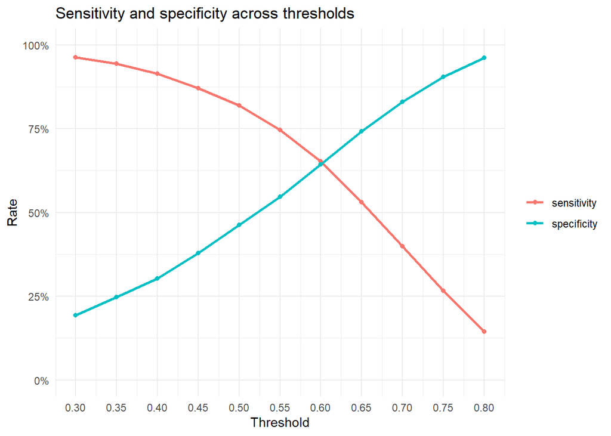

```r
sweep %>%
  pivot_longer(c(sensitivity, specificity),
               names_to = "measure", values_to = "rate") %>%
  ggplot(aes(x = threshold, y = rate, color = measure)) +
  geom_line(linewidth = 1) +
  geom_point() +
  scale_x_continuous(breaks = thresholds) +
  scale_y_continuous(labels = scales::percent, limits = c(0, 1)) +
  labs(x = "Threshold", y = "Rate", color = NULL,
       title = "Sensitivity and specificity across thresholds") +
  theme_minimal()
```

**4.4 Plotting ROC Curve**

```r
library(pROC)

roc_obj <- roc(response = test$recid, predictor = test$p_hat)

auc(roc_obj)
```

```
Area under the curve: 0.7064
```

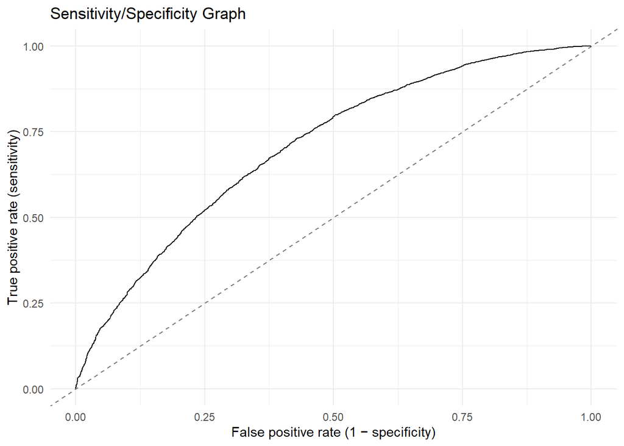

```r
ggroc(roc_obj, legacy.axes = TRUE) +
  geom_abline(linetype = "dashed", color = "grey50") +
  labs(x = "False positive rate (1 − specificity)",
       y = "True positive rate (sensitivity)",
       title = "Sensitivity/Specificity Graph") +
  theme_minimal()
```

The area under the curve is .71, which means that when the model is given one person who was rearrested and one who wasn’t at random, it will give the rearrested person a higher score ~71% of the time. This visual shows that the model is better at predicting rates of rearrest than random chance alone. It does not tell us whether this is a good threshold for determining policy or the individual or systemic cost of wrongly flagging someone.

# Part 5: Is it race-blind?

**5.1**

```r
test %>%
  group_by(Race) %>%
  summarize(
    n               = n(),
    share_high_risk = mean(pred_50 == 1),
    share_rearrested = mean(recid == 1),
    fpr = sum(pred_50 == 1 & recid == 0) / sum(recid == 0),
    fnr = sum(pred_50 == 0 & recid == 1) / sum(recid == 1)
  )
```

```
# A tibble: 2 × 6
  Race      n share_high_risk share_rearrested   fpr   fnr
  <chr> <int>           <dbl>            <dbl> <dbl> <dbl>
1 BLACK  4534           0.716            0.582 0.567 0.177
2 WHITE  3273           0.676            0.564 0.498 0.186
```

**5.2**

```r
errors_by_race <- function(t) {
  test %>%
    mutate(pred = as.integer(p_hat >= t)) %>%
    group_by(Race) %>%
    summarize(
      threshold        = t,
      n                = n(),
      share_high_risk  = mean(pred == 1),
      share_rearrested = mean(recid == 1),
      fpr = sum(pred == 1 & recid == 0) / sum(recid == 0),
      fnr = sum(pred == 0 & recid == 1) / sum(recid == 1)
    )
}

errors_by_race(0.3)
```

```
# A tibble: 2 × 7
  Race  threshold     n share_high_risk share_rearrested   fpr    fnr
  <chr>     <dbl> <int>           <dbl>            <dbl> <dbl>  <dbl>
1 BLACK       0.3  4534           0.911            0.582 0.834 0.0345
2 WHITE       0.3  3273           0.877            0.564 0.770 0.0401
```

```r
errors_by_race <- function(t) {
  test %>%
    mutate(pred = as.integer(p_hat >= t)) %>%
    group_by(Race) %>%
    summarize(
      threshold        = t,
      n                = n(),
      share_high_risk  = mean(pred == 1),
      share_rearrested = mean(recid == 1),
      fpr = sum(pred == 1 & recid == 0) / sum(recid == 0),
      fnr = sum(pred == 0 & recid == 1) / sum(recid == 1)
    )
}

errors_by_race(0.7)
```

```
# A tibble: 2 × 7
  Race  threshold     n share_high_risk share_rearrested   fpr   fnr
  <chr>     <dbl> <int>           <dbl>            <dbl> <dbl> <dbl>
1 BLACK       0.7  4534           0.303            0.582 0.174 0.605
2 WHITE       0.7  3273           0.299            0.564 0.165 0.596
```

```r
view(errors_by_race(0.7))
view(errors_by_race(0.5))
view(errors_by_race(.3))
```

```r
combined <- bind_rows(errors_by_race(0.7), errors_by_race(0.5), errors_by_race(0.3), .id = "source")
```

Even though race is not explicitly used as a predictor in the model, it does predict different values for both represented races. Additionally, Black individuals are predicted at higher risk rates for rearrest at each threshold than their white counterparts.

The share of high risk individuals from both demographics increases as the threshold decreases. However, the difference between share of high risk individuals associated with a threshold of .7 is < the difference between the share of high risk individuals associated with a threshold of .5 (~4 percentage points). The difference between the share of high risk individuals associated with a threshold of .5 is marginally > the difference between the share of high risk individuals associated with a threshold of .03 (~3 percentage points).

**5.3**

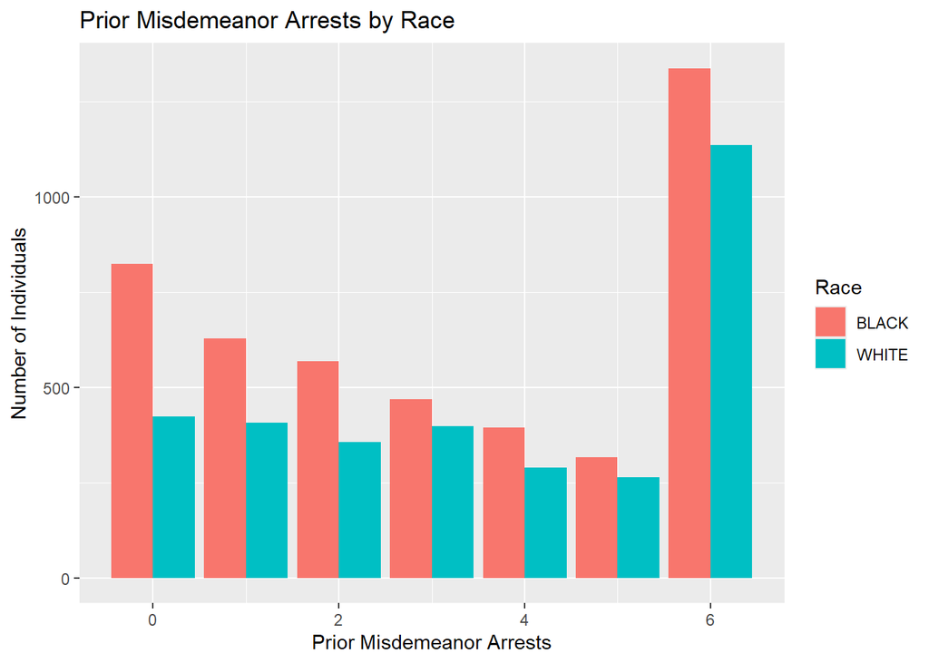

```r
ggplot(test, aes(x = prior_misd_arrests, fill = Race)) +
  geom_bar(position = "dodge") +
  scale_fill_hue() +
  labs(title = "Prior Misdemeanor Arrests by Race",
       x = "Prior Misdemeanor Arrests", y = "Number of Individuals")
```

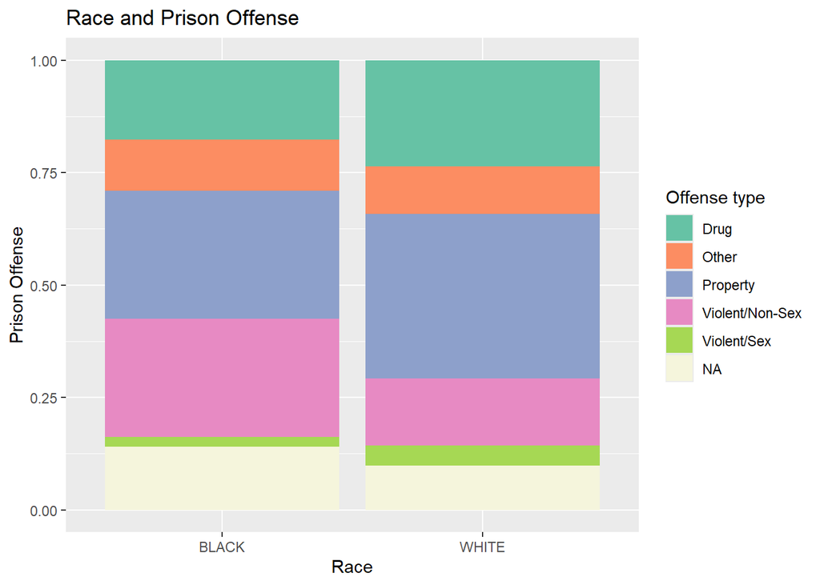

```r
ggplot(test, aes(x = Race, fill = factor(Prison_Offense))) +
  geom_bar(position = "fill") +
  scale_fill_brewer(palette = "Set2", na.value = "beige") +
  labs(title = "Race and Prison Offense",
       x = "Race", y = "Prison Offense", fill = "Offense type")
```

# Part 6: Does it hold up in places it hasn’t seen?

```r
pumas <- levels(train$puma)

cv_puma <- map_dfr(pumas, function(u) {
  cv_train <- train %>% filter(puma != u)
  cv_test  <- train %>% filter(puma == u)

  fit <- glm(formula(my_fit), family = binomial, data = cv_train)

  cv_test %>%
    mutate(pred = as.integer(predict(fit, newdata = cv_test,
                                     type = "response") >= 0.5)) %>%
    summarize(puma       = u,
              n          = n(),
              share_black = mean(Race == "BLACK"),
              accuracy   = mean(pred == recid),
              fpr        = sum(pred == 1 & recid == 0) / sum(recid == 0))
})
```

**6.1 PUMA Plotting**

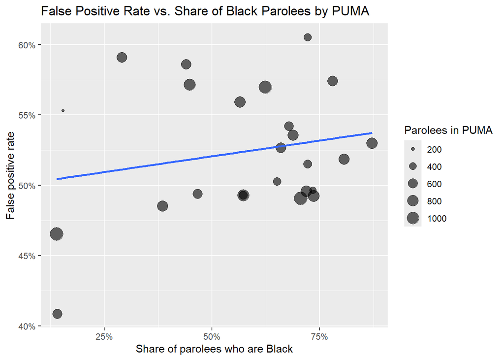

```r
ggplot(cv_puma, aes(x = share_black, y = fpr)) +
  geom_point(aes(size = n), alpha = 0.6) +
  geom_smooth(method = "lm", se = FALSE) +
  scale_x_continuous(labels = scales::percent) +
  scale_y_continuous(labels = scales::percent) +
  labs(title = "False Positive Rate vs. Share of Black Parolees by PUMA",
       x = "Share of parolees who are Black",
       y = "False positive rate",
       size = "Parolees in PUMA")
```

There appears to be a positive linear relationship between false positive rate and share of parolees who are Black. In other words, as the false positive rate increases, so does the puma share of parolees who are Black.

**6.2**

If I were to put ‘puma’ into the model as a predictor, I would assume it would make the model less race-blind because, in the US, geographic areas are systematically racially segregated. If the model knew residential location, it would have information that is a distilled proxy of race.

# Part 7: The memo

Dear Deputy Commissioner,

I have run an analysis on the data you provided. What follows will be an explanation of the findings and a recommendation for next steps.

I developed a risk assessment model to quantify parolees’ likelihood of being rearrested within three years upon release. The intention of the model is to guide data-driven parole decisions. Before I further detail the process and outcomes, it’s critical to note that there is no such thing as a perfect outcome or result. It is intended to produce useful information in guiding decision-making processes, and that is where its value ends. It is important to keep in mind that the ultimate decision must come from an integrated framework that recognizes the importance of both quantitative and qualitative research.

I ran the model on the data you provided and found that each additional prior felony arrest was associated with about 18% higher odds of rearrest, when all other factors remain stable. However, probability is most likely the most useful framework for deciding how to allocate resources, not odds. The distinction matters; Odds compares the chance someone is rearrested to the chance they are not, while probability is the chance someone is rearrested out of all possible outcomes.

The area under the curve is .71, which means that when the model is given one person who was rearrested and one who wasn’t at random, it will give the rearrested person a higher score ~71% of the time. This visual shows that the model is better at predicting rates of rearrest than random chance alone. It does not tell us whether this is a good threshold for determining policy or the individual or systemic cost of wrongly flagging someone.

You requested that the model be race-blind, but ultimately that is an impossible task. This data does not exist in a vacuum and is therefore unfeasible (and perhaps irresponsible) to disaggregate race from other predictors that invariably serve as proxies for race.

Use A: threshold of .7. For this use, wrongly flagging someone is the more costly mistake. Someone flagged in error would face more check-ins, electronic monitoring and faster revocation, even though they would not otherwise have been rearrested. That extra scrutiny raises the chance they’re sent back to prison for a technical violation, so the model could help cause the failure it was predicting. At 0.70, the model wrongly flags 17% of people who were not rearrested. At the default of 0.50, it wrongly flags 54%. The trade-off is that it catches only 40% of people who are rearrested. I think that trade-off is worth making: unnecessary supervision costs taxpayers money and restricts the civil liberties of people who have committed no further crimes.

Use B: no threshold. For this use, the costs reverse. If someone gets a case manager they didn’t strictly need, the main cost is money. If someone who needed housing or job support goes without it, the cost is a person set up to fail. Since missing people is the expensive mistake, the threshold should be as low as possible, and the lowest possible threshold is zero. Everyone leaving prison should have access to reentry support. It costs more up front, but it is likely to reduce rearrests and their costs later. If funding can’t cover everyone, I recommend a low threshold of 0.40, which reaches 91% of the people who were later rearrested.

I hope this provides useful insight.